# Flight Delay

Project 2: Flight Delay

By Gaofeng Huang

Class: DATS6103 Data Mining (19Spring) of 15:30-18:00, Thursday.

[Source: https://www.kaggle.com/usdot/flight-delays#flights.csv](https://www.kaggle.com/usdot/flight-delays#flights.csv)

Github: https://github.com/GH920/DATS6103-Project2  
Zenodo: https://sandbox.zenodo.org/record/267559#.XKwfgutKi8U

```python
import pandas as pd
import numpy as np
import matplotlib.pyplot as pp
import zipfile
```

```python
import seaborn as sns
sns.set(rc={'figure.figsize':(12,8)})
```

```python
# set the precision of 2 decimal place.
pd.set_option('display.precision',2)
# pd.options.display.float_format = '{:,.2f}'.format
```

```python
# zipfile.ZipFile('flight-delays.zip').extractall('.')
```

# Data Overview

Flight source: https://www.kaggle.com/usdot/flight-delays#flights.csv

```python
# read data of flight.csv
# a warning claims 'ORIGIN_AIRPORT' and 'DESTINATION_AIRPORT' have type of int data
flight_raw = pd.read_csv('flights.csv', dtype={'ORIGIN_AIRPORT': str,
                                               'DESTINATION_AIRPORT': str})
```

```python
# over 5 million rows, over 30 columns, quite a big data.
flight_raw.shape
```

```
(5819079, 31)
```

### Raw Variables (Column Names)

**YEAR**: Year of the Flight Trip  
**MONTH**: Month of the Flight Trip  
**DAY**: Day of the Flight Trip  
**DAY_OF_WEEK**: Day of week of the Flight Trip  
**AIRLINE**: Airline Identifier  
**FLIGHT_NUMBER**: Flight Identifier  
**TAIL_NUMBER**: Aircraft Identifier  
**ORIGIN_AIRPORT**: Starting Airport  
**DESTINATION_AIRPORT**: Destination Airport  
**SCHEDULED_DEPARTURE**: Planned Departure Time  
**DEPARTURE_TIME**: WHEEL_OFF - TAXI_OUT  
**DEPARTURE_DELAY**: Total Delay on Departure  
**TAXI_OUT**: The time duration elapsed between departure from the origin airport gate and wheels off  
**WHEELS_OFF**: The time point that the aircraft's wheels leave the ground  
**SCHEDULED_TIME**: Planned time amount needed for the flight trip  
**ELAPSED_TIME**: AIR_TIME + TAXI_IN + TAXI_OUT  
**AIR_TIME**: The time duration between wheels_off and wheels_on time  
**DISTANCE**: Distance between two airports  
**WHEELS_ON**: The time point that the aircraft's wheels touch on the ground  
**TAXI_IN**: The time duration elapsed between wheels-on and gate arrival at the destination airport  
**SCHEDULED_ARRIVAL**: Planned arrival time  
**ARRIVAL_TIME**: WHEELS_ON + TAXI_IN  
**ARRIVAL_DELAY**: ARRIVAL_TIME - SCHEDULED_ARRIVAL  
**DIVERTED**: Aircraft landed on airport that out of schedule  
**CANCELLED**: Flight Cancelled (1 = cancelled)  
**CANCELLATION_REASON**: Reason for Cancellation of flight: A - Airline/Carrier; B - Weather; C - National Air System; D - Security  
**AIR_SYSTEM_DELAY**: Delay caused by air system  
**SECURITY_DELAY**: Delay caused by security  
**AIRLINE_DELAY**: Delay caused by the airline  
**LATE_AIRCRAFT_DELAY**: Delay caused by aircraft  
**WEATHER_DELAY**: Delay caused by weather

```python
# take a look at the basic statistics
flight_raw.loc[:,['DEPARTURE_TIME', 'DEPARTURE_DELAY',
                  'AIR_TIME', 'DISTANCE', 'ARRIVAL_TIME',
                  'ARRIVAL_DELAY', 'DIVERTED', 'CANCELLED'
                 ]].describe()
```

|  | DEPARTURE_TIME | DEPARTURE_DELAY | AIR_TIME | DISTANCE | ARRIVAL_TIME | ARRIVAL_DELAY | DIVERTED | CANCELLED |
| --- | --- | --- | --- | --- | --- | --- | --- | --- |
| count | 5.73e+06 | 5.73e+06 | 5.71e+06 | 5.82e+06 | 5.73e+06 | 5.71e+06 | 5.82e+06 | 5.82e+06 |
| mean | 1.34e+03 | 9.37e+00 | 1.14e+02 | 8.22e+02 | 1.48e+03 | 4.41e+00 | 2.61e-03 | 1.54e-02 |
| std | 4.96e+02 | 3.71e+01 | 7.22e+01 | 6.08e+02 | 5.26e+02 | 3.93e+01 | 5.10e-02 | 1.23e-01 |
| min | 1.00e+00 | -8.20e+01 | 7.00e+00 | 2.10e+01 | 1.00e+00 | -8.70e+01 | 0.00e+00 | 0.00e+00 |
| 25% | 9.21e+02 | -5.00e+00 | 6.00e+01 | 3.73e+02 | 1.06e+03 | -1.30e+01 | 0.00e+00 | 0.00e+00 |
| 50% | 1.33e+03 | -2.00e+00 | 9.40e+01 | 6.47e+02 | 1.51e+03 | -5.00e+00 | 0.00e+00 | 0.00e+00 |
| 75% | 1.74e+03 | 7.00e+00 | 1.44e+02 | 1.06e+03 | 1.92e+03 | 8.00e+00 | 0.00e+00 | 0.00e+00 |
| max | 2.40e+03 | 1.99e+03 | 6.90e+02 | 4.98e+03 | 2.40e+03 | 1.97e+03 | 1.00e+00 | 1.00e+00 |

## Data Cleaning and Preprocessing

```python
# Count the number of NAN and different values in each column
def count_NA_levels(data):
    for i in data.columns:
        x = data[i].unique()
        y = data[i]
        count_na = data.shape[0] - (y.dropna(axis=0, how='any')).shape[0]
        if count_na > 0:
            print(i + '({} NaN): '.format(count_na) + str(len(x)))
        else:
            print(i + '(no NaN): ' + str(len(x)))
```

```python
count_NA_levels(flight_raw)
```

```
YEAR(no NaN): 1
MONTH(no NaN): 12
DAY(no NaN): 31
DAY_OF_WEEK(no NaN): 7
AIRLINE(no NaN): 14
FLIGHT_NUMBER(no NaN): 6952
TAIL_NUMBER(14721 NaN): 4898
ORIGIN_AIRPORT(no NaN): 628
DESTINATION_AIRPORT(no NaN): 629
SCHEDULED_DEPARTURE(no NaN): 1321
DEPARTURE_TIME(86153 NaN): 1441
DEPARTURE_DELAY(86153 NaN): 1218
TAXI_OUT(89047 NaN): 185
WHEELS_OFF(89047 NaN): 1441
SCHEDULED_TIME(6 NaN): 551
ELAPSED_TIME(105071 NaN): 713
AIR_TIME(105071 NaN): 676
DISTANCE(no NaN): 1363
WHEELS_ON(92513 NaN): 1441
TAXI_IN(92513 NaN): 186
SCHEDULED_ARRIVAL(no NaN): 1435
ARRIVAL_TIME(92513 NaN): 1441
ARRIVAL_DELAY(105071 NaN): 1241
DIVERTED(no NaN): 2
CANCELLED(no NaN): 2
CANCELLATION_REASON(5729195 NaN): 5
AIR_SYSTEM_DELAY(4755640 NaN): 571
SECURITY_DELAY(4755640 NaN): 155
AIRLINE_DELAY(4755640 NaN): 1068
LATE_AIRCRAFT_DELAY(4755640 NaN): 696
WEATHER_DELAY(4755640 NaN): 633
```

```python
flight_dropna = flight_raw.dropna(axis=0, how='any',
                                  subset=['ARRIVAL_DELAY', 'DEPARTURE_DELAY'])
```

```python
count_NA_levels(flight_dropna)
```

```
YEAR(no NaN): 1
MONTH(no NaN): 12
DAY(no NaN): 31
DAY_OF_WEEK(no NaN): 7
AIRLINE(no NaN): 14
FLIGHT_NUMBER(no NaN): 6946
TAIL_NUMBER(no NaN): 4896
ORIGIN_AIRPORT(no NaN): 628
DESTINATION_AIRPORT(no NaN): 629
SCHEDULED_DEPARTURE(no NaN): 1320
DEPARTURE_TIME(no NaN): 1440
DEPARTURE_DELAY(no NaN): 1212
TAXI_OUT(no NaN): 184
WHEELS_OFF(no NaN): 1440
SCHEDULED_TIME(no NaN): 549
ELAPSED_TIME(no NaN): 712
AIR_TIME(no NaN): 675
DISTANCE(no NaN): 1350
WHEELS_ON(no NaN): 1440
TAXI_IN(no NaN): 184
SCHEDULED_ARRIVAL(no NaN): 1434
ARRIVAL_TIME(no NaN): 1440
ARRIVAL_DELAY(no NaN): 1240
DIVERTED(no NaN): 1
CANCELLED(no NaN): 1
CANCELLATION_REASON(5714008 NaN): 1
AIR_SYSTEM_DELAY(4650569 NaN): 571
SECURITY_DELAY(4650569 NaN): 155
AIRLINE_DELAY(4650569 NaN): 1068
LATE_AIRCRAFT_DELAY(4650569 NaN): 696
WEATHER_DELAY(4650569 NaN): 633
```

```python
flight_dropna.shape
```

```
(5714008, 31)
```

```python
flight_clean = flight_dropna.loc[:,['MONTH','DAY','DAY_OF_WEEK',
                           'AIRLINE','ORIGIN_AIRPORT','DESTINATION_AIRPORT',
                           'DEPARTURE_DELAY','ARRIVAL_DELAY', 'DISTANCE',
                           'AIR_SYSTEM_DELAY','SECURITY_DELAY','AIRLINE_DELAY',
                           'LATE_AIRCRAFT_DELAY','WEATHER_DELAY'
                          ]]
```

```python
flight_clean.shape
```

```
(5714008, 14)
```

```python
count_NA_levels(flight_clean)
```

```
MONTH(no NaN): 12
DAY(no NaN): 31
DAY_OF_WEEK(no NaN): 7
AIRLINE(no NaN): 14
ORIGIN_AIRPORT(no NaN): 628
DESTINATION_AIRPORT(no NaN): 629
DEPARTURE_DELAY(no NaN): 1212
ARRIVAL_DELAY(no NaN): 1240
DISTANCE(no NaN): 1350
AIR_SYSTEM_DELAY(4650569 NaN): 571
SECURITY_DELAY(4650569 NaN): 155
AIRLINE_DELAY(4650569 NaN): 1068
LATE_AIRCRAFT_DELAY(4650569 NaN): 696
WEATHER_DELAY(4650569 NaN): 633
```

```python
delay_over15min = flight_clean.dropna(subset=['AIR_SYSTEM_DELAY','SECURITY_DELAY',
                                        'AIRLINE_DELAY','LATE_AIRCRAFT_DELAY',
                                        'WEATHER_DELAY'], how='all')
```

```python
count_NA_levels(delay_over15min)
```

```
MONTH(no NaN): 12
DAY(no NaN): 31
DAY_OF_WEEK(no NaN): 7
AIRLINE(no NaN): 14
ORIGIN_AIRPORT(no NaN): 625
DESTINATION_AIRPORT(no NaN): 625
DEPARTURE_DELAY(no NaN): 1190
ARRIVAL_DELAY(no NaN): 1142
DISTANCE(no NaN): 1339
AIR_SYSTEM_DELAY(no NaN): 570
SECURITY_DELAY(no NaN): 154
AIRLINE_DELAY(no NaN): 1067
LATE_AIRCRAFT_DELAY(no NaN): 695
WEATHER_DELAY(no NaN): 632
```

```python
delay_over15min.shape
```

```
(1063439, 14)
```

```python
flight_clean[flight_clean.ARRIVAL_DELAY >= 15].shape
```

```
(1063439, 14)
```

```python
flight = flight_clean.drop(['AIR_SYSTEM_DELAY','SECURITY_DELAY','AIRLINE_DELAY',
                           'LATE_AIRCRAFT_DELAY','WEATHER_DELAY'], axis=1)
```

```python
flight.shape
```

```
(5714008, 9)
```

```python
# create a column to measure delay or not
# DELAY_OR_NOT: True (ARRIVAL_DELAY > 0), False (ARRIVAL_DELAY <= 0)

flight['DELAY_OR_NOT'] = flight.loc[:, ['ARRIVAL_DELAY']] > 0
flight.head()
```

|  | MONTH | DAY | DAY_OF_WEEK | AIRLINE | ORIGIN_AIRPORT | DESTINATION_AIRPORT | DEPARTURE_DELAY | ARRIVAL_DELAY | DISTANCE | DELAY_OR_NOT |
| --- | --- | --- | --- | --- | --- | --- | --- | --- | --- | --- |
| 0 | 1 | 1 | 4 | AS | ANC | SEA | -11.0 | -22.0 | 1448 | False |
| 1 | 1 | 1 | 4 | AA | LAX | PBI | -8.0 | -9.0 | 2330 | False |
| 2 | 1 | 1 | 4 | US | SFO | CLT | -2.0 | 5.0 | 2296 | True |
| 3 | 1 | 1 | 4 | AA | LAX | MIA | -5.0 | -9.0 | 2342 | False |
| 4 | 1 | 1 | 4 | AS | SEA | ANC | -1.0 | -21.0 | 1448 | False |

### Variables (Column Names)

**MONTH**: Month of the Flight Trip  
**DAY**: Day of the Flight Trip  
**DAY_OF_WEEK**: Day of week of the Flight Trip  
**AIRLINE**: Airline Identifier  
**ORIGIN_AIRPORT**: Starting Airport  
**DESTINATION_AIRPORT**: Destination Airport  
**DEPARTURE_DELAY**: Total Delay on Departure  
**ARRIVAL_DELAY**: ARRIVAL_TIME - SCHEDULED_ARRIVAL  
**DISTANCE**: Distance between two airports

**DELAY_OR_NOT**: True (ARRIVAL_DELAY > 0), False (ARRIVAL_DELAY <= 0)

**AIR_SYSTEM_DELAY**: Delay caused by air system  
**SECURITY_DELAY**: Delay caused by security  
**AIRLINE_DELAY**: Delay caused by the airline  
**LATE_AIRCRAFT_DELAY**: Delay caused by aircraft  
**WEATHER_DELAY**: Delay caused by weather

## Data Analysis and Visualization

### Departure Delay and Arrival Delay

Airline source: https://www.kaggle.com/usdot/flight-delays#airlines.csv

```python
# read data of airlines.csv for the full name of airlines
airline_name = pd.read_csv('airlines.csv')
airline_name
```

|  | IATA_CODE | AIRLINE |
| --- | --- | --- |
| 0 | UA | United Air Lines Inc. |
| 1 | AA | American Airlines Inc. |
| 2 | US | US Airways Inc. |
| 3 | F9 | Frontier Airlines Inc. |
| 4 | B6 | JetBlue Airways |
| 5 | OO | Skywest Airlines Inc. |
| 6 | AS | Alaska Airlines Inc. |
| 7 | NK | Spirit Air Lines |
| 8 | WN | Southwest Airlines Co. |
| 9 | DL | Delta Air Lines Inc. |
| 10 | EV | Atlantic Southeast Airlines |
| 11 | HA | Hawaiian Airlines Inc. |
| 12 | MQ | American Eagle Airlines Inc. |
| 13 | VX | Virgin America |

```python
# merge the fullname of airline companies into flight data
flight_fullname = flight.rename(columns={'AIRLINE': 'IATA_CODE'})
flight_fullname = flight_fullname.merge(airline_name, on='IATA_CODE')
```

```python
# Make clear on DEPARTURE_DELAY and ARRIVAL_DELAY
# Delay caused before departure or after departure?

airline_deparr_plot = flight_fullname.loc[:, ['AIRLINE',
                                     'DEPARTURE_DELAY',
                                     'ARRIVAL_DELAY']].groupby('AIRLINE').mean()
```

```python
airline_deparr_plot
```

| AIRLINE | DEPARTURE_DELAY | ARRIVAL_DELAY |
| --- | --- | --- |
| Alaska Airlines Inc. | 1.72 | -0.98 |
| American Airlines Inc. | 8.83 | 3.45 |
| American Eagle Airlines Inc. | 9.97 | 6.46 |
| Atlantic Southeast Airlines | 8.62 | 6.59 |
| Delta Air Lines Inc. | 7.31 | 0.19 |
| Frontier Airlines Inc. | 13.30 | 12.50 |
| Hawaiian Airlines Inc. | 0.47 | 2.02 |
| JetBlue Airways | 11.44 | 6.68 |
| Skywest Airlines Inc. | 7.74 | 5.85 |
| Southwest Airlines Co. | 10.52 | 4.37 |
| Spirit Air Lines | 15.88 | 14.47 |
| US Airways Inc. | 6.08 | 3.71 |
| United Air Lines Inc. | 14.33 | 5.43 |
| Virgin America | 8.99 | 4.74 |

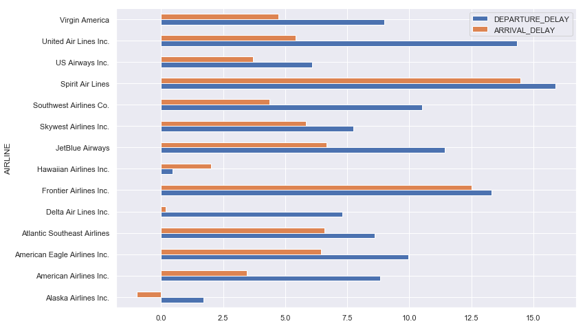

```python
airline_deparr_plot.plot.barh(figsize=(12,8), stacked=False)
pp.show()
```

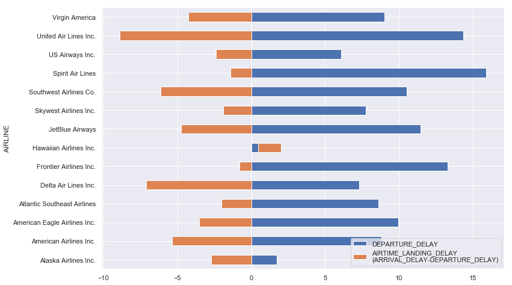

```python
# ARRIVAL_DELAY is the total delay, i.e. delay result of this flight
# extract the delay in the airtime and landing
airline_deparr_plot['ARRIVAL_DELAY'] = (- airline_deparr_plot['DEPARTURE_DELAY']
                                        + airline_deparr_plot['ARRIVAL_DELAY'])
ax = airline_deparr_plot.plot.barh(figsize=(12,8), stacked=True)
ax.legend(['DEPARTURE_DELAY', 'AIRTIME_LANDING_DELAY\n(ARRIVAL_DELAY-DEPARTURE_DELAY)'])
# ax.title('')
pp.show()
```

## Airlines

```python
# use this function to select which airline we are interested
def flight_airline(airline):
    return flight.loc[flight['AIRLINE']==airline]
```

```python
# airline_marketshare(flight_fullname[flight_fullname.DELAY_OR_NOT > 0],
#                     titlehere='Flight Delay Weight of Airlines in 2015')
```

```python
# draw the number of delays for [what, e.g. MONTH] we want to groupby
def draw_count_delay(data, select, kind='bar'):
    data_select = data.loc[:, [select, 'DELAY_OR_NOT']].groupby(select).sum()
    ax = data_select.plot(kind=kind, figsize=(10,6))
    ax.legend(['Number of Delays'])
    pp.show()
```

```python
# draw_count_delay(flight, 'MONTH')
```

```python
# airline_marketshare(flight,
#                     by='MONTH', titlehere='Flight Delay Weight by Month in 2015')
```

```python
# airline_marketshare(flight[flight.DELAY_OR_NOT > 0],
#                     by='MONTH', titlehere='Flight Delay Weight by Month in 2015')
```

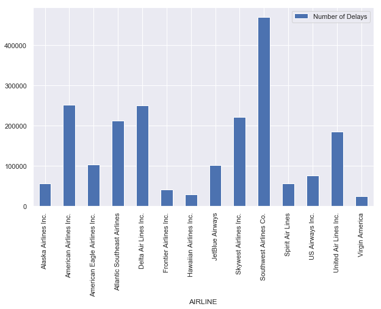

```python
draw_count_delay(flight_fullname, 'AIRLINE')
```

```python
# split by month
flight_month = flight.loc[:, ['MONTH']].groupby('MONTH').sum()
get_airline = flight.AIRLINE.unique()

for a in get_airline:
    flight_month[a] = flight_airline(a).loc[:, ['MONTH', 'DELAY_OR_NOT']]\
                                        .groupby('MONTH').sum()
#set full name
flight_month.columns = flight_fullname.AIRLINE.unique()
```

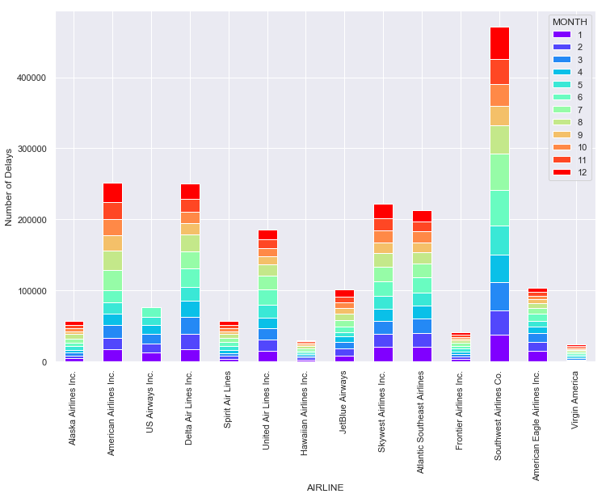

```python
ax = flight_month.T.plot(kind='bar', stacked=True, figsize=(12,8), colormap='rainbow')
ax.set(ylabel='Number of Delays', xlabel='AIRLINE')
pp.show()
```

```python
# view the market share of these airlines

def airline_marketshare(data=flight_fullname, by='AIRLINE', titlehere='Market Share of Airlines in 2015'):
    df = data.loc[:, [by]]
    df['Share %'] = 1
    top = df.groupby(by).sum().sort_values(by='Share %',ascending=False)
    top = top.reset_index()

    sharePlot = top['Share %'].plot.pie(subplots=True,
                                         autopct='%0.2f%%',
                                         fontsize=12,
                                         figsize=(10,10),
                                         legend=False,
                                         labels=top[by],
                                         shadow=False,
                                         explode=(0.01,0.02,0.03,0.04,0.05,0.06,
                                                  0.07,0.08,0.1,0.15,
                                                  0.2,0.25,
                                                  0.3,0.35)[:len(data[by].unique())],
                                         startangle=90,
                                         colormap='summer',
                                         title=titlehere
                                       )

    pp.show()
```

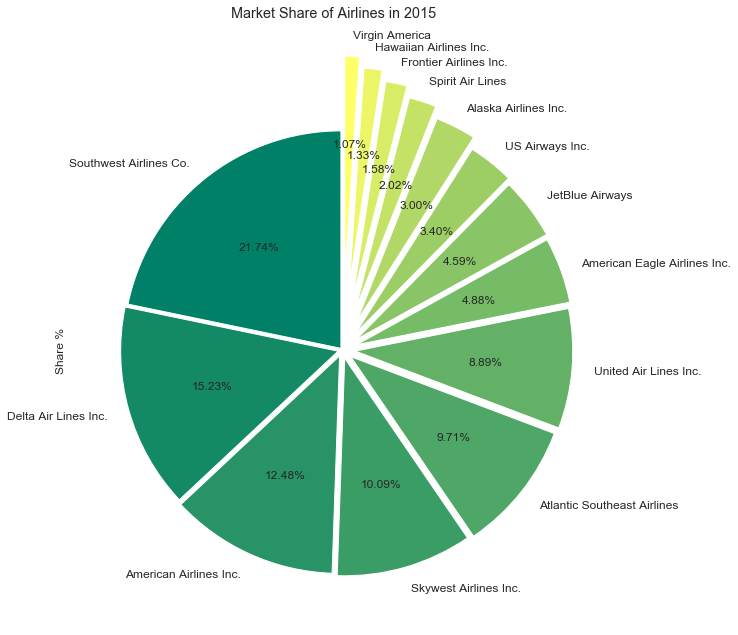

```python
airline_marketshare()
```

```python
def draw_pct_delay(data, select, kind='bar'):
    data_select = (100*(data.loc[:, [select, 'DELAY_OR_NOT']].groupby(select).sum())
                   /(data.loc[:, [select, 'DELAY_OR_NOT']].groupby(select).count()))
    data_select.plot(kind=kind)
    pp.show()
```

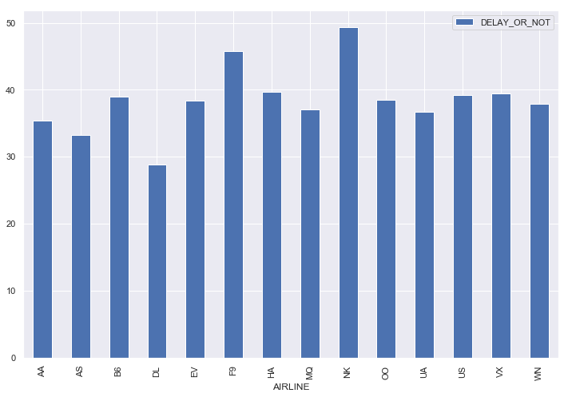

```python
draw_pct_delay(flight, 'AIRLINE')
```

```python
def draw_pct_delay_month(data, select, kind='bar'):
    for m in range(12):
        data_select['{}'.format(m)] = (100*(data.loc[:, [select, 'DELAY_OR_NOT']].groupby(select).sum())
                       /(data.loc[:, [select, 'DELAY_OR_NOT']].groupby(select).count()))
    data_select.plot(kind=kind, stacked=True)
    pp.show()
```

```python
flight_month_pct = flight.loc[:, ['MONTH']].groupby('MONTH').sum()
airline = flight.AIRLINE.unique()

for a in airline:
    flight_a = flight_airline(a)
    flight_month_pct[a] = 100*(flight_a.loc[:, ['MONTH', 'DELAY_OR_NOT']].groupby('MONTH').sum()
                          /flight_a.shape[0])
flight_month_pct.columns = flight_fullname.AIRLINE.unique()
```

```python
flight_month_pct.T
```

| MONTH | 1 | 2 | 3 | 4 | 5 | 6 | 7 | 8 | 9 | 10 | 11 | 12 |
| --- | --- | --- | --- | --- | --- | --- | --- | --- | --- | --- | --- | --- |
| Alaska Airlines Inc. | 2.60 | 2.31 | 2.63 | 2.33 | 2.79 | 2.89 | 3.21 | 3.74 | 2.63 | 2.63 | 2.64 | 2.82 |
| American Airlines Inc. | 2.52 | 2.14 | 2.62 | 2.27 | 2.20 | 2.37 | 4.04 | 3.77 | 2.95 | 3.17 | 3.37 | 3.95 |
| US Airways Inc. | 6.54 | 6.46 | 6.90 | 6.63 | 5.77 | 6.98 | NaN | NaN | NaN | NaN | NaN | NaN |
| Delta Air Lines Inc. | 2.02 | 2.48 | 2.79 | 2.51 | 2.25 | 2.96 | 2.81 | 2.70 | 1.91 | 1.82 | 2.07 | 2.50 |
| Spirit Air Lines | 3.57 | 3.58 | 3.51 | 3.74 | 4.75 | 5.19 | 4.41 | 4.84 | 3.67 | 3.69 | 3.88 | 4.55 |
| United Air Lines Inc. | 3.02 | 3.02 | 3.24 | 2.96 | 3.44 | 4.37 | 3.79 | 3.18 | 2.20 | 2.31 | 2.30 | 2.84 |
| Hawaiian Airlines Inc. | 3.72 | 3.99 | 3.89 | 2.76 | 3.09 | 3.19 | 3.67 | 4.47 | 3.51 | 2.95 | 2.06 | 2.39 |
| JetBlue Airways | 3.30 | 3.82 | 3.55 | 2.80 | 2.35 | 2.90 | 3.44 | 3.70 | 2.89 | 3.11 | 2.83 | 4.23 |
| Skywest Airlines Inc. | 3.64 | 3.23 | 3.08 | 2.94 | 3.16 | 3.52 | 3.50 | 3.46 | 2.63 | 2.89 | 2.98 | 3.55 |
| Atlantic Southeast Airlines | 3.72 | 3.47 | 3.81 | 3.25 | 3.28 | 3.87 | 3.40 | 3.03 | 2.41 | 2.76 | 2.64 | 2.81 |
| Frontier Airlines Inc. | 3.93 | 3.72 | 4.28 | 4.03 | 4.28 | 4.38 | 4.44 | 3.82 | 2.52 | 2.83 | 4.07 | 3.46 |
| Southwest Airlines Co. | 3.04 | 2.71 | 3.21 | 3.12 | 3.32 | 4.00 | 4.13 | 3.21 | 2.24 | 2.47 | 2.84 | 3.60 |
| American Eagle Airlines Inc. | 5.32 | 4.69 | 4.32 | 3.23 | 3.12 | 3.64 | 2.92 | 2.48 | 1.88 | 1.70 | 1.80 | 2.03 |
| Virgin America | 2.73 | 2.62 | 3.10 | 2.88 | 3.66 | 3.51 | 3.89 | 3.76 | 2.93 | 3.16 | 3.04 | 4.20 |

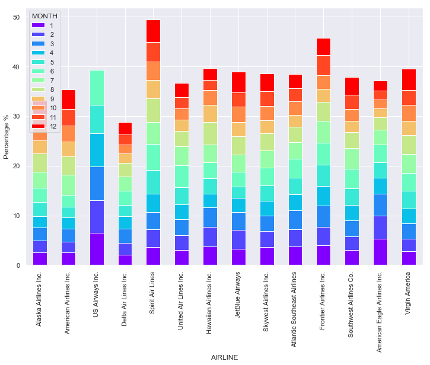

```python
ax = flight_month_pct.T.plot.bar(figsize=(12,8), stacked=True, colormap='rainbow')
ax.set(ylabel='Percentage %',xlabel='AIRLINE')
pp.show()
```

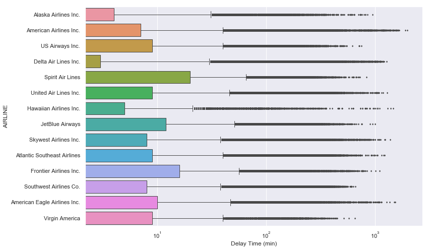

```python
# boxplot of delay time (min) and airlines

a = flight_fullname.loc[:, ['ARRIVAL_DELAY','AIRLINE']]
ax = sns.boxplot(y='AIRLINE', x='ARRIVAL_DELAY', data=a, linewidth=1, fliersize=2)
ax.set(xscale="log", xlabel='Delay Time (min)') #will ignore the negative value (no delays)
pp.show()
```

## Airports

```python
import plotly
import plotly.plotly as py
from plotly.graph_objs import *
py.sign_in('ghuang920','8iaLjzlhEXT9N0gAYZ1O')
```

```python
plotly.offline.init_notebook_mode()
```

Airport source: https://www.kaggle.com/usdot/flight-delays#airports.csv

```python
# read airport data for longitude and latitude
# so we can draw it in the map
airport = pd.read_csv('airports.csv')
```

```python
# get the delay rate of (origin or destination) airports
def get_airport_plot(select):
    data_select = airport.rename(columns={'IATA_CODE': select})
    data_select_plot = pd.merge(data_select,
                               flight.loc[:, [select, 'DELAY_OR_NOT']]\
                               .groupby(select).mean().reset_index())

    data_select_plot['text_plot'] = ('Airport: ' + data_select_plot['AIRPORT'] + '<br>'
                                    + 'City: ' + data_select_plot['CITY'] + '<br>'
                                    + 'State: ' + data_select_plot['STATE'] + '<br>'
                                    + 'Percentage of Delay: '
                                    + ((data_select_plot['DELAY_OR_NOT']*10000)\
                                       .astype(int)/100).astype(str) + '%<br>')

    return data_select_plot
```

```python
airport_origin_plot = get_airport_plot('ORIGIN_AIRPORT')
# airport_origin_plot.head()
```

```python
#colorscale made for plotting
scale = [[0.0, 'rgb(0,100,0)'],[0.2, 'rgb(34,139,34)'],
         [0.4, 'rgb(60,179,60)'],[0.6, 'rgb(173,255,47)'],
         [0.8, 'rgb(255,215,0)'],[1.0, 'rgb(255,99,71)']]
```

```python
# draw the (origin or destination) airports in the map w.r.t delay rate
def delay_pct(dataplot, titlehere, filename):
    #data
    data = [dict(type='scattergeo',
                 lat=dataplot['LATITUDE'],
                 lon=dataplot['LONGITUDE'],
                 marker=dict(
                     autocolorscale=False,
                     cmax=50,
                     cmin=0,
                     color= dataplot['DELAY_OR_NOT']*100,
                     colorbar=dict(title="Percentage of Delay (%)"),
                     colorscale=scale, #'Viridis'
                     line=dict(
                         color="rgba(102,102,102)",
                         width=1
                     ),
                     opacity=0.8,
                     size=8
                 ),

                 text=dataplot['text_plot'],
                 mode='markers',
                )]

    #layout
    layout = dict(title= titlehere + '<br> Hover for value',
                 geo=dict(scope='USA',
                          projection=dict(type='albers usa'),
                          showlakes=True,
                          showland=True,
                          lakecolor='rgb(95,145,237)',
                          landcolor='rgb(250,250,250)',
                         )
                 )

    fig = dict(data=data, layout=layout)
    return py.iplot(fig, validate=False, filename=filename)
```

```python
delay_pct(airport_origin_plot, 'Flight Delay Rate of Origin Airports in 2015', 'Delay_2015_Origin')
```

[interactive chart not shown]

```python
airport_destination_plot = get_airport_plot('DESTINATION_AIRPORT')
# airport_destination_plot.head()
```

```python
delay_pct(airport_destination_plot, 'Flight Delay Rate of Destination Airports in 2015', 'Delay_2015_Destination')
```

[interactive chart not shown]

```python
# get the delay time info w.r.t (origin or destination) airports
def get_airport_delaytime_plot(select, val):
    #merge flight dataset and airport dataset
    data_select = airport.rename(columns={'IATA_CODE': select})
    data_select_plot = pd.merge(data_select,
                               flight.loc[:, [select, val]]\
                               .groupby(select).mean().reset_index())

    #for the hover text when plotting
    data_select_plot['text_plot'] = ('Airport: ' + data_select_plot['AIRPORT'] + '<br>'
                                    + 'City: ' + data_select_plot['CITY'] + '<br>'
                                    + 'State: ' + data_select_plot['STATE'] + '<br>'
                                    + 'Average Delay Minutes: '
                                    + ((data_select_plot[val]*100)\
                                       .astype(int)/100).astype(str) + '<br>')

    return data_select_plot
```

```python
airport_origin_delaytime_plot = get_airport_delaytime_plot('ORIGIN_AIRPORT', 'ARRIVAL_DELAY')
# airport_origin_delaytime_plot.head()
```

```python
# delay as origin vs. delay as destination (delay rate)
a = airport_origin_plot.rename(columns={'ORIGIN_AIRPORT': 'APT',
                                        'DELAY_OR_NOT': 'DELAYasORIGIN'})
b = airport_destination_plot.rename(columns={'DESTINATION_AIRPORT': 'APT',
                                             'DELAY_OR_NOT': 'DELAYasDEST'})
c = a.loc[:,['APT','DELAYasORIGIN']].merge(b.loc[:,['APT','DELAYasDEST']], on='APT')
c.set_index('APT').corr()
```

|  | DELAYasORIGIN | DELAYasDEST |
| --- | --- | --- |
| DELAYasORIGIN | 1.00 | 0.54 |
| DELAYasDEST | 0.54 | 1.00 |

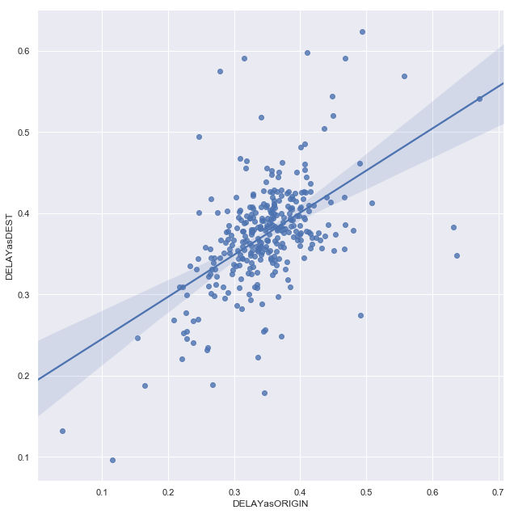

```python
sns.lmplot(x='DELAYasORIGIN', y='DELAYasDEST',
           data=c, height=9)
pp.show()
```

```python
#draw the (origin or destination) airports in the map visualized by delay time
def delay_time(dataplot, titlehere, filename):
    #data
    data = [dict(type='scattergeo',
                 lat=dataplot['LATITUDE'],
                 lon=dataplot['LONGITUDE'],
                 marker=dict(
                     autocolorscale=False,
                     cmax=15,
                     cmin=-20,
                     color= dataplot[dataplot.columns[-2]],
                     colorbar=dict(title="Average Delay Minutes"),
                     colorscale=scale, #'Viridis'
                     line=dict(
                         color="rgba(102,102,102)",
                         width=1
                     ),
                     opacity=0.8,
                     size=8
                 ),

                 text=dataplot['text_plot'],
                 mode='markers',
                )]

    #layout
    layout = dict(title=titlehere + '<br> Hover for value',
                 geo=dict(scope='USA',
                          projection=dict(type='albers usa'),
                          showlakes=True,
                          showland=True,
                          lakecolor='rgb(95,145,237)',
                          landcolor='rgb(250,250,250)',
                         )
                 )

    fig = dict(data=data, layout=layout)
    return py.iplot(fig, validate=False, filename=filename)
```

```python
delay_time(airport_origin_delaytime_plot, 'Average Flight Delay Time of Origin Airports in 2015', 'Avg_DelayTime_Origin')
```

[interactive chart not shown]

```python
airport_dest_delaytime_plot = get_airport_delaytime_plot('DESTINATION_AIRPORT', 'ARRIVAL_DELAY')
# airport_dest_delaytime_plot.head()
```

```python
delay_time(airport_dest_delaytime_plot, 'Average Flight Delay Time of Destination Airports in 2015', 'Avg_DelayTime_Destionation')
```

[interactive chart not shown]

```python
# delay as origin vs. delay as destination (delay time)
a = airport_origin_delaytime_plot.rename(columns={'ORIGIN_AIRPORT': 'APT',
                                        'ARRIVAL_DELAY': 'DELAYasORIGIN'})
b = airport_dest_delaytime_plot.rename(columns={'DESTINATION_AIRPORT': 'APT',
                                             'ARRIVAL_DELAY': 'DELAYasDEST'})
c = a.loc[:,['APT','DELAYasORIGIN']].merge(b.loc[:,['APT','DELAYasDEST']], on='APT')
c.set_index('APT').corr()
```

|  | DELAYasORIGIN | DELAYasDEST |
| --- | --- | --- |
| DELAYasORIGIN | 1.00 | 0.66 |
| DELAYasDEST | 0.66 | 1.00 |

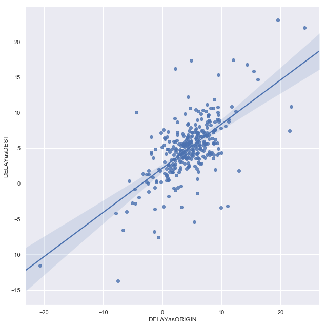

```python
sns.lmplot(x='DELAYasORIGIN', y='DELAYasDEST',
           data=c, height=9)
pp.show()
```

```python
# get the info (origin and destination airports) of each flight route
def route(flight):
    #for origin airports info
    a = flight.loc[:, ['ORIGIN_AIRPORT', 'DESTINATION_AIRPORT', 'ARRIVAL_DELAY']]
    a['AtoB'] = a['ORIGIN_AIRPORT'] + a['DESTINATION_AIRPORT']
    b = a.loc[:,['AtoB','ARRIVAL_DELAY']].groupby('AtoB').mean()
    b['IATA_CODE'] = b.index.str[:3]
    c = pd.merge(airport, b.reset_index())
    c.rename(columns={'IATA_CODE': 'ORIGIN_AIRPORT'}, inplace=True)
    c_sorted = c.set_index('AtoB').sort_index()

    #for destination airports info
    b.drop('IATA_CODE', axis=1, inplace=True)
    b['IATA_CODE'] = b.index.str[3:]
    d = pd.merge(airport, b.reset_index())
    d.rename(columns={'IATA_CODE': 'DESTINATION_AIRPORT'}, inplace=True)
    d_sorted = d.set_index('AtoB').sort_index()

    return (c_sorted, d_sorted)
```

```python
#draw the route map visualized by the delay time
def delay_time_route(airline='AA'):
    #data

    route_origin, route_destination = route(flight_airline(airline))

    #draw the airport points in the map
    data = [dict(type='scattergeo',
                 lat=route_origin['LATITUDE'],
                 lon=route_origin['LONGITUDE'],
                 marker=dict(
                     color='#FFD700',
                     line=dict(
                         color="rgba(102,102,102)",
                         width=1
                     ),
                     opacity=0.8,
                     size=6
                 ),
                 mode='markers',
                )]

    #draw the flight route in the map
    for i in range(route_origin.shape[0]):
        data += [dict(
            lat=[route_origin['LATITUDE'][i], route_destination['LATITUDE'][i]],
            line=dict(
                color='#4682B4',
                width=1
            ),
            locationmode="USA-states",
            lon=[route_origin['LONGITUDE'][i], route_destination['LONGITUDE'][i]],
            mode="lines",
            text=('From: ' + (route_origin['AIRPORT'][i])
                  + '<br>To: ' + route_destination['AIRPORT'][i]
                  + '<br>Avg. Delay: '
                  + ((route_origin['ARRIVAL_DELAY'][i]*100).astype(int)/100).astype(str)
                  + ' mins'
                 ),
            opacity=(route_origin['ARRIVAL_DELAY'][i])/30 if (route_origin['ARRIVAL_DELAY'][i])>0 else 0,
            type="scattergeo"
        )]

    #layout
    layout = dict(title='Average Delay Time of Airline {} Route in 2015'.format(airline)
                  + '<br> Hover for value',
                 geo=dict(scope='north america',
                          projection=dict(type="azimuthal equal area"),
                          showlakes=True,
                          showland=True,
                          lakecolor='rgb(95,145,237)',
                          landcolor='rgb(250,250,250)'
                         ),
                  showlegend=False
                 )

    fig = dict(data=data, layout=layout)
    return py.iplot(fig, validate=False, filename='Delay_Route_2015_{}'.format(airline))
```

```python
delay_time_route('DL')
```

[interactive chart not shown]

```python
delay_time_route('AA')
```

[interactive chart not shown]

```python
delay_time_route('HA')
```

[interactive chart not shown]

```python
# get the main reason of a delay

delay_over15min['DELAY_REASON'] = None
for reason in delay_over15min.columns[-6:-1]:
    delay_over15min['DELAY_REASON'][delay_over15min[reason]
                                    /delay_over15min['ARRIVAL_DELAY'] > 0.5] = reason
```

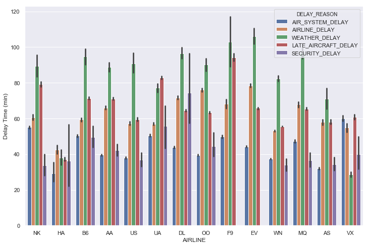

```python
# find the main delay reason of each airline

# calculate the reason of delays w.r.t the delay time (min)
# i.e. if a delay occurs, how long is the delay time in this delay reason?
ax = sns.barplot(x='AIRLINE', y='ARRIVAL_DELAY',
                data=delay_over15min,
                hue='DELAY_REASON')
ax.set(ylabel='Delay Time (min)')
pp.show()
```

```python
# calculate the reason caused delays in percentage
# i.e. if a delay occurs, what is the probability of this delay reason?
count_delay_reason = delay_over15min.loc[:, ['AIRLINE', 'AIR_SYSTEM_DELAY',
                                             'AIRLINE_DELAY', 'LATE_AIRCRAFT_DELAY',
                                             'SECURITY_DELAY', 'WEATHER_DELAY'
                                            ]]
count_delay_reason.set_index('AIRLINE', inplace=True)
count_delay_reason = 100*(((count_delay_reason>0).reset_index().groupby('AIRLINE').sum())
                      /count_delay_reason.groupby('AIRLINE').count())
count_delay_reason
```

| AIRLINE | AIR_SYSTEM_DELAY | AIRLINE_DELAY | LATE_AIRCRAFT_DELAY | SECURITY_DELAY | WEATHER_DELAY |
| --- | --- | --- | --- | --- | --- |
| AA | 54.02 | 52.70 | 44.21 | 0.56 | 7.65 |
| AS | 66.65 | 37.41 | 35.19 | 1.12 | 3.88 |
| B6 | 57.31 | 65.34 | 53.54 | 0.73 | 3.67 |
| DL | 54.42 | 53.49 | 42.46 | 0.05 | 10.03 |
| EV | 58.24 | 49.41 | 50.19 | 0.00 | 2.61 |
| F9 | 76.65 | 48.86 | 49.38 | 0.00 | 2.46 |
| HA | 3.77 | 85.81 | 56.59 | 0.34 | 6.64 |
| MQ | 59.14 | 44.98 | 53.06 | 0.51 | 15.04 |
| NK | 82.93 | 50.57 | 34.25 | 0.87 | 2.70 |
| OO | 54.28 | 36.30 | 57.92 | 0.32 | 4.11 |
| UA | 47.61 | 63.02 | 47.62 | 0.02 | 7.19 |
| US | 64.87 | 53.95 | 37.36 | 1.02 | 4.71 |
| VX | 45.81 | 37.74 | 45.81 | 0.67 | 17.59 |
| WN | 41.32 | 61.08 | 68.96 | 0.23 | 4.26 |

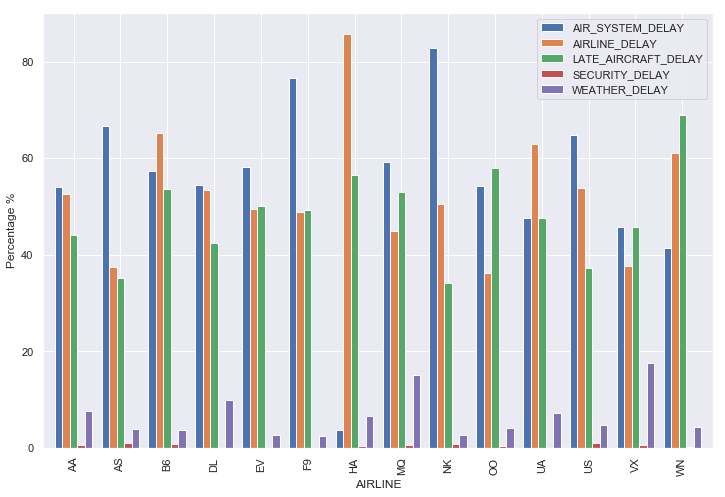

```python
ax = count_delay_reason.plot.bar(width=0.8)
ax.set(ylabel='Percentage %')
pp.show()
```

Comparing with the previous bar chart, weather delays are less probable occured. However, if a weather delay happens, it will cause a longer delay time in average.